# Vaccines: Many Beliefs Pilot 2

# Scale Internal Consistency Reliability

Below are computed chronbach’s alpha for all scales along with more detailed analyses of scales that are problematic.

## Holistic Balance

```r
hb <- c("hb_hb_1",
"hb_hb_2",
"hb_hb_3",
"hb_hb_4")
hb.alpha <- psych::alpha(df[,hb])
hb.alpha$total$raw_alpha
```

```
[1] 0.8457005
```

## Naturalism

```r
nat <- c("nat_nat_1",
"nat_nat_2r",
"nat_nat_3",
"nat_nat_4",
"nat_nat_5")
naturalism.alpha <- psych::alpha(df[,nat])
naturalism.alpha$total$raw_alpha
```

```
[1] 0.8411908
```

```r
omega(df[,nat])
```

```
Test of homogeneity
The robust F statistic is  0.32
with a p-value  0.8995

The omega is 0.8748096.
About 9.57% of cases were downweighted.
```

## Disease Rarity

**NOTE**: we previously scored this one kind of strangely, so it’s now been relabeld as “diseaseRare” to indicate that it reflects participants’ belief the diseases are extremely rare.

```r
diseaseRare <- c("diseaseRare_diseaseRare_1",
"diseaseRare_diseaseRare_2",
"diseaseRare_diseaseRare_3")
diseaseRare.alpha <- psych::alpha(df[,diseaseRare])
diseaseRare.alpha$total$raw_alpha
```

```
[1] 0.8526036
```

```r
alpha(df[,diseaseRare])
```

```
Test of tau-equavilence
The robust F statistic is  1.61
with a p-value  0.2055
The alpha is 0.9008884.
About 14.89% of cases were downweighted.
```

## Disease Severity

```r
diseaseSevere <- c("diseaseSevere_diseaseSevere_1",
"diseaseSevere_diseaseSevere_2",
"diseaseSevere_diseaseSevere_3",
"diseaseSevere_diseaseSevere_4",
"diseaseSevere_diseaseSevere_5r")
diseaseSevere.alpha <- psych::alpha(df[,diseaseSevere])
diseaseSevere.alpha$total$raw_alpha
```

```
[1] 0.7725724
```

```r
diseaseSevere.alpha
```

```
Reliability analysis
Call: psych::alpha(x = df[, diseaseSevere])

  raw_alpha std.alpha G6(smc) average_r S/N   ase mean sd
      0.77      0.78    0.77      0.41 3.5 0.037  5.2  1

 lower alpha upper     95% confidence boundaries
0.7 0.77 0.85

 Reliability if an item is dropped:
                               raw_alpha std.alpha G6(smc) average_r S/N alpha se
diseaseSevere_diseaseSevere_1       0.66      0.67    0.61      0.33 2.0    0.057
diseaseSevere_diseaseSevere_2       0.76      0.76    0.75      0.45 3.3    0.042
diseaseSevere_diseaseSevere_3       0.75      0.76    0.75      0.44 3.1    0.041
diseaseSevere_diseaseSevere_4       0.72      0.73    0.68      0.40 2.6    0.047
diseaseSevere_diseaseSevere_5r      0.76      0.76    0.73      0.44 3.1    0.041

 Item statistics
                                n raw.r std.r r.cor r.drop mean  sd
diseaseSevere_diseaseSevere_1  94  0.85  0.86  0.86   0.75  5.2 1.3
diseaseSevere_diseaseSevere_2  94  0.66  0.67  0.52   0.47  5.0 1.3
diseaseSevere_diseaseSevere_3  94  0.68  0.68  0.54   0.48  5.1 1.4
diseaseSevere_diseaseSevere_4  94  0.74  0.75  0.70   0.58  4.9 1.3
diseaseSevere_diseaseSevere_5r 94  0.71  0.68  0.57   0.49  5.5 1.6

Non missing response frequency for each item
                                  1    2    3    4    5    6    7 miss
diseaseSevere_diseaseSevere_1  0.01 0.02 0.03 0.29 0.18 0.30 0.17    0
diseaseSevere_diseaseSevere_2  0.00 0.02 0.11 0.21 0.27 0.27 0.13    0
diseaseSevere_diseaseSevere_3  0.01 0.05 0.03 0.28 0.11 0.36 0.16    0
diseaseSevere_diseaseSevere_4  0.02 0.00 0.04 0.37 0.21 0.21 0.14    0
diseaseSevere_diseaseSevere_5r 0.03 0.00 0.11 0.12 0.14 0.28 0.33    0
```

### Diagnosing

Here are histograms of each item

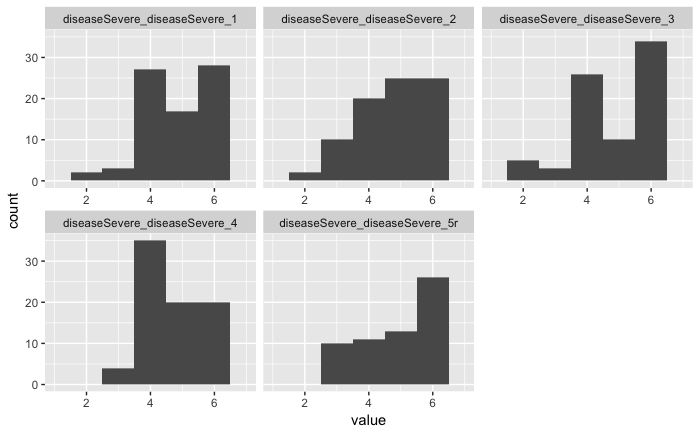

```r
library(ggplot2)
library(reshape2)
ggplot(data = melt(df[,diseaseSevere]), mapping = aes(x = value)) +
    geom_histogram(bins = 7) + facet_wrap(~variable, scales = 'free_x') + xlim(1,7)
```

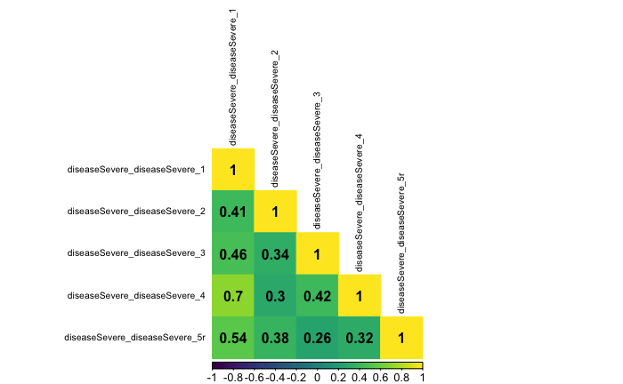

```r
corrplot(cor(df[,diseaseSevere]),
         type="lower",
         order="alpha",
         tl.cex=.65,
         tl.col="black",
         method="color",
         addCoef.col="black",
         col=viridis(128))
```

Now try McDonald’s Omega (which might be better for all–though some problem with scales with only 3 items?). The robust estimates mostly seem higher than the normal estimates.

```r
library(coefficientalpha)
omega(df[,diseaseSevere])
```

```
Test of homogeneity
The robust F statistic is  2.619
with a p-value  0.0295

**The F test rejected homogeneity**

The omega is 0.8084946.
About 10.64% of cases were downweighted.
```

## Vaccine Effectiveness

```r
vaccEff <- c("vaccEff_vaccEff_1",
"vaccEff_vaccEff_2r",
"vaccEff_vaccEff_3r",
"vaccEff_vaccEff_4")
vaccEff.alpha <- psych::alpha(df[,vaccEff])
vaccEff.alpha$total$raw_alpha
```

```
[1] 0.8628902
```

## Vaccine Danger

```r
vaccDanger <- c("vaccDanger_vaccDanger_1",
"vaccDanger_vaccDanger_2",
"vaccDanger_vaccDanger_3",
"vaccDanger_vaccDanger_4r")
vaccDanger.alpha <- psych::alpha(df[,vaccDanger])
vaccDanger.alpha$total$raw_alpha
```

```
[1] 0.899375
```

## Vaccines are toxic

```r
vaccTox <- c("vaccTox_vaccTox_1",
"vaccTox_vaccTox_2",
"vaccTox_vaccTox_3",
"vaccTox_vaccTox_4r")
vaccTox.alpha <- psych::alpha(df[,vaccTox])
vaccTox.alpha$total$raw
```

```
[1] 0.9313677
```

## Medical Skepticism

```r
medSkept <- c("medSkept_medSkept_1",
"medSkept_medSkept_2r",
"medSkept_medSkept_3",
"medSkept_medSkept_4",
"medSkept_medSkept_5",
"medSkept_medSkept_6")
medSkept.alpha <- psych::alpha(df[,medSkept])
medSkept.alpha$total$raw_alpha
```

```
[1] 0.8341088
```

## Vaccination Intentions

```r
vaccIntent <- c("vaccIntent_vaccIntent_1r",
"vaccIntent_vaccIntent_2",
"vaccIntent_vaccIntent_3r",
"vaccIntent_vaccIntent_4",
"vaccIntent_vaccIntent_5r")
vaccIntent.alpha <- psych::alpha(df[,vaccIntent])
vaccIntent.alpha$total$raw_alpha
```

```
[1] 0.8471399
```

## Infant vulnerability (general)

Reliabilty here is somewhat low.

```r
infantVuln <- c("infantVuln_infantVuln_1r",
"infantVuln_infantVuln_2",
"infantVuln_infantVuln_3")
infantVuln.alpha <- psych::alpha(df[,infantVuln])
infantVuln.alpha$total$raw_alpha
```

```
[1] 0.6887596
```

```r
infantVuln.alpha
```

```
Reliability analysis
Call: psych::alpha(x = df[, infantVuln])

  raw_alpha std.alpha G6(smc) average_r S/N   ase mean sd
      0.69      0.71    0.65      0.45 2.5 0.056  5.1  1

 lower alpha upper     95% confidence boundaries
0.58 0.69 0.8

 Reliability if an item is dropped:
                         raw_alpha std.alpha G6(smc) average_r  S/N alpha se
infantVuln_infantVuln_1r      0.74      0.74    0.59      0.59 2.83    0.054
infantVuln_infantVuln_2       0.62      0.64    0.47      0.47 1.76    0.074
infantVuln_infantVuln_3       0.44      0.46    0.29      0.29 0.84    0.110

 Item statistics
                          n raw.r std.r r.cor r.drop mean  sd
infantVuln_infantVuln_1r 94  0.80  0.74  0.51   0.43  3.9 1.5
infantVuln_infantVuln_2  94  0.74  0.79  0.64   0.49  5.9 1.1
infantVuln_infantVuln_3  94  0.84  0.86  0.78   0.64  5.5 1.2

Non missing response frequency for each item
                            1    2    3    4    5    6    7 miss
infantVuln_infantVuln_1r 0.04 0.15 0.28 0.20 0.15 0.13 0.05    0
infantVuln_infantVuln_2  0.00 0.02 0.02 0.04 0.21 0.36 0.34    0
infantVuln_infantVuln_3  0.00 0.01 0.05 0.13 0.24 0.35 0.21    0
```

## Parental Duty

This remains middling.

```r
parDuty <- c("parentDuty_parentDuty_1",
"parentDuty_parentDuty_2",
"parentDuty_parentDuty_3",
"parentDuty_parentDuty_4")
parDuty.alpha <- psych::alpha(df[,parDuty])
parDuty.alpha$total$raw_alpha
```

```
[1] 0.7309793
```

```r
parDuty.alpha
```

```
Reliability analysis
Call: psych::alpha(x = df[, parDuty])

  raw_alpha std.alpha G6(smc) average_r S/N   ase mean   sd
      0.73      0.75     0.7      0.43 3.1 0.043  5.5 0.98

 lower alpha upper     95% confidence boundaries
0.65 0.73 0.82

 Reliability if an item is dropped:
                        raw_alpha std.alpha G6(smc) average_r S/N alpha se
parentDuty_parentDuty_1      0.67      0.68    0.58      0.41 2.1    0.057
parentDuty_parentDuty_2      0.68      0.72    0.63      0.46 2.6    0.053
parentDuty_parentDuty_3      0.67      0.70    0.61      0.44 2.3    0.054
parentDuty_parentDuty_4      0.66      0.69    0.60      0.43 2.2    0.059

 Item statistics
                         n raw.r std.r r.cor r.drop mean   sd
parentDuty_parentDuty_1 94  0.72  0.78  0.68   0.58  6.1 0.92
parentDuty_parentDuty_2 94  0.75  0.73  0.58   0.51  5.1 1.43
parentDuty_parentDuty_3 94  0.72  0.75  0.63   0.53  5.9 1.15
parentDuty_parentDuty_4 94  0.81  0.77  0.65   0.56  5.1 1.66

Non missing response frequency for each item
                           1    2    3    4    5    6    7 miss
parentDuty_parentDuty_1 0.00 0.00 0.01 0.04 0.20 0.37 0.37    0
parentDuty_parentDuty_2 0.01 0.05 0.05 0.19 0.21 0.31 0.17    0
parentDuty_parentDuty_3 0.00 0.01 0.03 0.11 0.10 0.41 0.34    0
parentDuty_parentDuty_4 0.01 0.09 0.12 0.11 0.23 0.19 0.26    0
```

## Parental Expertise (and patient individualism)

As does this.

```r
parExpert <- c("parentExpert_parentExpert_1",
"parentExpert_parentExpert_2",
"parentExpert_parentExpert_3",
"parentExpert_parentExpert_4",
"parentExpert_parentExpert_5")
parExpert.alpha <- psych::alpha(df[,parExpert])
parExpert.alpha$total$raw_alpha
```

```
[1] 0.7703476
```

```r
parExpert.alpha
```

```
Reliability analysis
Call: psych::alpha(x = df[, parExpert])

  raw_alpha std.alpha G6(smc) average_r S/N   ase mean  sd
      0.77      0.76    0.77      0.39 3.2 0.037    4 1.1

 lower alpha upper     95% confidence boundaries
0.7 0.77 0.84

 Reliability if an item is dropped:
                            raw_alpha std.alpha G6(smc) average_r S/N alpha se
parentExpert_parentExpert_1      0.68      0.67    0.66      0.34 2.1    0.054
parentExpert_parentExpert_2      0.69      0.69    0.68      0.36 2.2    0.051
parentExpert_parentExpert_3      0.79      0.79    0.77      0.48 3.7    0.035
parentExpert_parentExpert_4      0.75      0.74    0.73      0.41 2.8    0.039
parentExpert_parentExpert_5      0.71      0.70    0.71      0.37 2.3    0.050

 Item statistics
                             n raw.r std.r r.cor r.drop mean  sd
parentExpert_parentExpert_1 94  0.82  0.81  0.78   0.69  4.3 1.5
parentExpert_parentExpert_2 94  0.80  0.78  0.74   0.64  3.6 1.6
parentExpert_parentExpert_3 94  0.52  0.57  0.39   0.32  5.4 1.2
parentExpert_parentExpert_4 94  0.67  0.68  0.56   0.46  3.9 1.5
parentExpert_parentExpert_5 94  0.78  0.76  0.68   0.60  3.0 1.6

Non missing response frequency for each item
                               1    2    3    4    5    6    7 miss
parentExpert_parentExpert_1 0.05 0.05 0.19 0.19 0.29 0.19 0.03    0
parentExpert_parentExpert_2 0.12 0.17 0.18 0.18 0.29 0.03 0.03    0
parentExpert_parentExpert_3 0.00 0.02 0.06 0.10 0.31 0.33 0.18    0
parentExpert_parentExpert_4 0.04 0.16 0.23 0.19 0.23 0.12 0.02    0
parentExpert_parentExpert_5 0.20 0.27 0.15 0.14 0.19 0.05 0.00    0
```

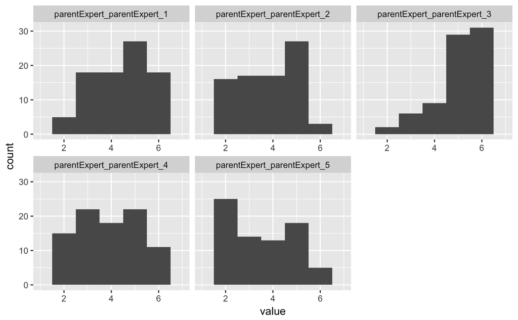

```r
library(ggplot2)
library(reshape2)
ggplot(data = melt(df[,parExpert]), mapping = aes(x = value)) +
    geom_histogram(bins = 7) + facet_wrap(~variable, scales = 'free_x') + xlim(1,7)
```

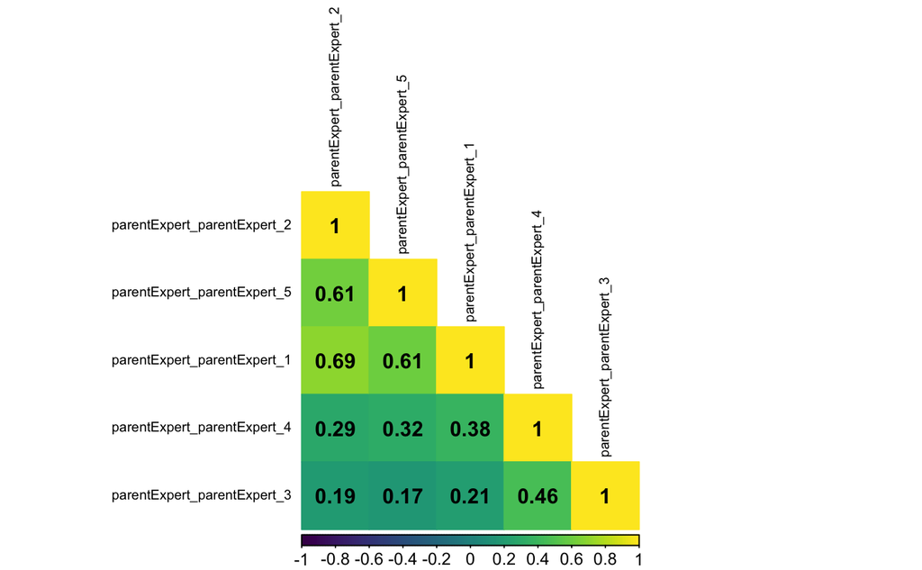

```r
corrplot(cor(df[,parExpert]),
         type="lower",
         order="AOE",
         tl.cex=.65,
         tl.col="black",
         method="color",
         addCoef.col="black",
         col=viridis(128))
```

```r
psych::alpha(df[, c("parentExpert_parentExpert_1",
"parentExpert_parentExpert_2",
"parentExpert_parentExpert_5")])
```

```
Reliability analysis
Call: psych::alpha(x = df[, c("parentExpert_parentExpert_1", "parentExpert_parentExpert_2",
    "parentExpert_parentExpert_5")])

  raw_alpha std.alpha G6(smc) average_r S/N   ase mean  sd
      0.84      0.84    0.78      0.64 5.3 0.029  3.6 1.3

 lower alpha upper     95% confidence boundaries
0.78 0.84 0.9

 Reliability if an item is dropped:
                            raw_alpha std.alpha G6(smc) average_r S/N alpha se
parentExpert_parentExpert_1      0.76      0.76    0.61      0.61 3.2    0.049
parentExpert_parentExpert_2      0.75      0.76    0.61      0.61 3.1    0.050
parentExpert_parentExpert_5      0.82      0.82    0.69      0.69 4.5    0.037

 Item statistics
                             n raw.r std.r r.cor r.drop mean  sd
parentExpert_parentExpert_1 94  0.87  0.88  0.79   0.72  4.3 1.5
parentExpert_parentExpert_2 94  0.88  0.88  0.80   0.73  3.6 1.6
parentExpert_parentExpert_5 94  0.85  0.85  0.72   0.66  3.0 1.6

Non missing response frequency for each item
                               1    2    3    4    5    6    7 miss
parentExpert_parentExpert_1 0.05 0.05 0.19 0.19 0.29 0.19 0.03    0
parentExpert_parentExpert_2 0.12 0.17 0.18 0.18 0.29 0.03 0.03    0
parentExpert_parentExpert_5 0.20 0.27 0.15 0.14 0.19 0.05 0.00    0
```

## Infant immune system has limited capacity

Reliability much better now. Perhaps still not as high as we’d like but seriously improved.

```r
immCap <- c("infantImmLimCap_infantImmLimCap_1",
"infantImmLimCap_infantImmLimCap_2r",
"infantImmLimCap_infantImmLimCap_3",
"infantImmLimCap_infantImmLimCap_4")
immCap.alpha <- psych::alpha(df[,immCap])
immCap.alpha$total$raw_alpha
```

```
[1] 0.7659238
```

```r
immCap.alpha
```

```
Reliability analysis
Call: psych::alpha(x = df[, immCap])

  raw_alpha std.alpha G6(smc) average_r S/N   ase mean sd
      0.77      0.76    0.74      0.44 3.2 0.038  4.2  1

 lower alpha upper     95% confidence boundaries
0.69 0.77 0.84

 Reliability if an item is dropped:
                                   raw_alpha std.alpha G6(smc) average_r S/N alpha se
infantImmLimCap_infantImmLimCap_1       0.74      0.74    0.69      0.48 2.8    0.046
infantImmLimCap_infantImmLimCap_2r      0.80      0.80    0.74      0.57 4.1    0.036
infantImmLimCap_infantImmLimCap_3       0.62      0.62    0.55      0.35 1.6    0.067
infantImmLimCap_infantImmLimCap_4       0.65      0.64    0.58      0.37 1.8    0.062

 Item statistics
                                    n raw.r std.r r.cor r.drop mean  sd
infantImmLimCap_infantImmLimCap_1  94  0.75  0.73  0.59   0.52  4.7 1.4
infantImmLimCap_infantImmLimCap_2r 94  0.61  0.64  0.43   0.37  3.4 1.2
infantImmLimCap_infantImmLimCap_3  94  0.86  0.85  0.82   0.71  4.0 1.4
infantImmLimCap_infantImmLimCap_4  94  0.84  0.84  0.79   0.69  4.6 1.3

Non missing response frequency for each item
                                      1    2    3    4    5    6    7 miss
infantImmLimCap_infantImmLimCap_1  0.00 0.06 0.16 0.19 0.28 0.20 0.11    0
infantImmLimCap_infantImmLimCap_2r 0.04 0.15 0.36 0.31 0.09 0.04 0.01    0
infantImmLimCap_infantImmLimCap_3  0.03 0.14 0.17 0.28 0.24 0.10 0.04    0
infantImmLimCap_infantImmLimCap_4  0.00 0.05 0.16 0.27 0.28 0.19 0.05    0
```

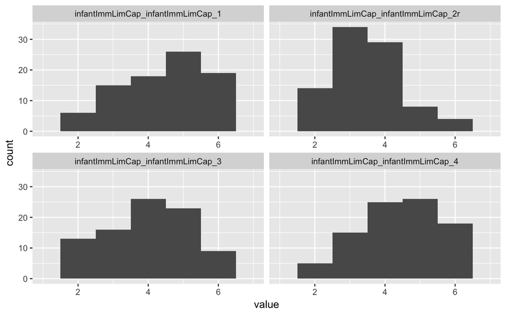

```r
library(ggplot2)
library(reshape2)
ggplot(data = melt(df[,immCap]), mapping = aes(x = value)) +
    geom_histogram(bins = 7) + facet_wrap(~variable, scales = 'free_x') + xlim(1,7)
```

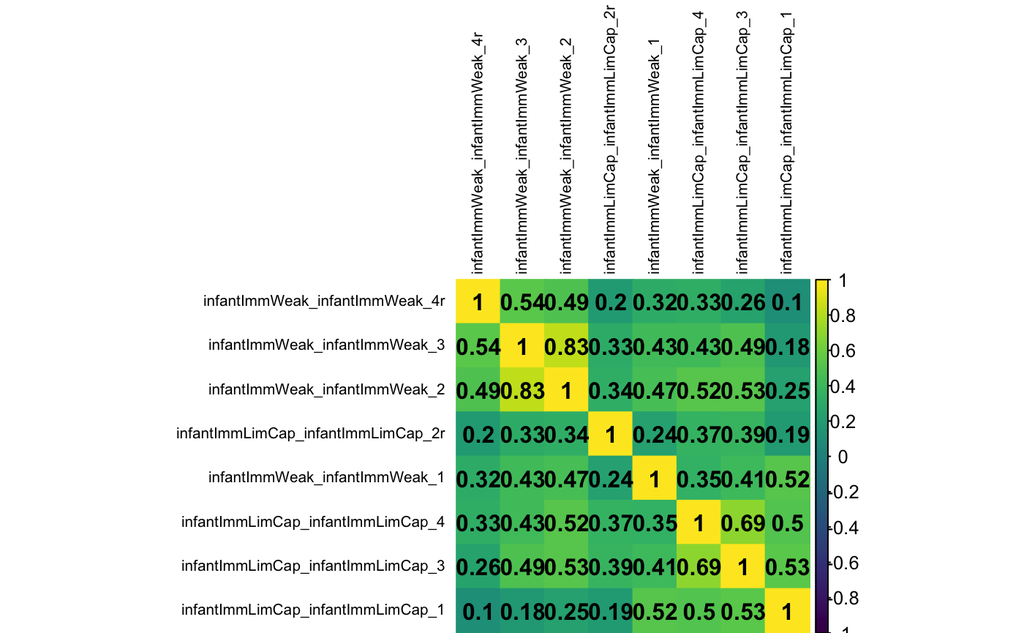

```r
corrplot(cor(df[,c(immCap,immWeak)]),
         order="AOE",
         tl.cex=.65,
         tl.col="black",
         method="color",
         addCoef.col="black",
         col=viridis(128))
```

```r
psych::alpha(df[,c(immCap,immWeak)])
```

```
Reliability analysis
Call: psych::alpha(x = df[, c(immCap, immWeak)])

  raw_alpha std.alpha G6(smc) average_r S/N   ase mean   sd
      0.84      0.84    0.87       0.4 5.3 0.024  4.4 0.96

 lower alpha upper     95% confidence boundaries
0.79 0.84 0.89

 Reliability if an item is dropped:
                                   raw_alpha std.alpha G6(smc) average_r S/N alpha se
infantImmLimCap_infantImmLimCap_1       0.84      0.84    0.85      0.43 5.2    0.025
infantImmLimCap_infantImmLimCap_2r      0.84      0.84    0.87      0.44 5.4    0.025
infantImmLimCap_infantImmLimCap_3       0.81      0.81    0.84      0.38 4.2    0.030
infantImmLimCap_infantImmLimCap_4       0.81      0.81    0.84      0.38 4.3    0.029
infantImmWeak_infantImmWeak_1           0.83      0.83    0.85      0.40 4.7    0.027
infantImmWeak_infantImmWeak_2           0.80      0.81    0.82      0.37 4.1    0.031
infantImmWeak_infantImmWeak_3           0.81      0.81    0.82      0.38 4.3    0.030
infantImmWeak_infantImmWeak_4r          0.84      0.84    0.86      0.43 5.2    0.025

 Item statistics
                                    n raw.r std.r r.cor r.drop mean  sd
infantImmLimCap_infantImmLimCap_1  94  0.60  0.59  0.53   0.46  4.7 1.4
infantImmLimCap_infantImmLimCap_2r 94  0.53  0.55  0.44   0.41  3.4 1.2
infantImmLimCap_infantImmLimCap_3  94  0.77  0.78  0.76   0.68  4.0 1.4
infantImmLimCap_infantImmLimCap_4  94  0.75  0.76  0.73   0.66  4.6 1.3
infantImmWeak_infantImmWeak_1      94  0.70  0.68  0.61   0.56  4.5 1.6
infantImmWeak_infantImmWeak_2      94  0.80  0.80  0.80   0.72  4.8 1.4
infantImmWeak_infantImmWeak_3      94  0.77  0.77  0.77   0.68  4.9 1.4
infantImmWeak_infantImmWeak_4r     94  0.59  0.59  0.50   0.45  4.1 1.4

Non missing response frequency for each item
                                      1    2    3    4    5    6    7 miss
infantImmLimCap_infantImmLimCap_1  0.00 0.06 0.16 0.19 0.28 0.20 0.11    0
infantImmLimCap_infantImmLimCap_2r 0.04 0.15 0.36 0.31 0.09 0.04 0.01    0
infantImmLimCap_infantImmLimCap_3  0.03 0.14 0.17 0.28 0.24 0.10 0.04    0
infantImmLimCap_infantImmLimCap_4  0.00 0.05 0.16 0.27 0.28 0.19 0.05    0
infantImmWeak_infantImmWeak_1      0.03 0.10 0.16 0.20 0.17 0.22 0.12    0
infantImmWeak_infantImmWeak_2      0.02 0.04 0.13 0.17 0.30 0.24 0.10    0
infantImmWeak_infantImmWeak_3      0.02 0.03 0.11 0.16 0.31 0.24 0.13    0
infantImmWeak_infantImmWeak_4r     0.03 0.09 0.24 0.23 0.22 0.15 0.03    0
```